# Joshua French

2021-02-11

# Data exploration

Based on Chapter 1 of LMWR2, Chapter 1 of ALR4

## Data analysis process

1. Define a question of interest.
2. Collect relevant data.
3. Analyze the data.
4. Interpret your analysis.
5. Make a decision.

“The formulation of a problem is often more essential than its solution, which may be merely a matter of mathematical or experimental skill” - Albert Einstein

### Problem Formulation

- Understand the physical background.
  - Statisticians often work in collaboration with others and need to understand something about the subject area.
- Understand the objective.
  - What are your goals?
  - Make sure you know what the client wants.
- Put the problem into statistical terms.
  - This is often the most challenging step and where irreparable errors are sometimes made.
  - That a statistical method can read in and process the data is not enough. The results of an inapt analysis may be meaningless.

### Data collection

Data collection:

- How the data were collected has a crucial impact on what conclusions can be made.
  - Are the data observational or experimental?
  - Are the data a sample of convenience or were they obtained via a designed sample survey?
- Is there nonresponse bias?
  - The data you do not see may be just as important as the data you do see.
- Are there missing values?
  - This is a common problem that is troublesome and time consuming to handle.
  - How are the data coded? How are the qualitative variables represented?
- What are the units of measurement?
- Beware of data entry errors and other corruption of the data.
  - Perform some data sanity checks.

## Data exploration

An initial exploration of the data should be performed prior to any formal analysis or modeling.

Initial data analysis should consist of numerical summaries and appropriate plots.

### Numerical summaries of data

Statistics can be used to numerically summarize aspects of the data:

- mean
- standard deviation (SD)
- maximum and minimum
- correlation
- other measures, as appropriate

### Visual summaries of data

Plots can provide a useful visual summary of the data.

- For one numerical variable: boxplots, histograms, density plots, etc.
- For two numerical variables: scatterplots.
- For three or more variables, construct interactive and dynamic graphics.
- For one categorial variable: bar charts

Good graphics are essential in data analysis.

- They help us avoid mistakes.
- They help us decide on a model.
- They help communicate the results of our analysis.
- Graphics can be more convincing than text at times.

### What to look for

When summarizing the data, look for:

- outliers
- data-entry errors
- skewness
- unusual distributions
- patterns or structure

## Kidney Example

The National Institute of Diabetes and Digestive and Kidney Diseases conducted a study on 768 adult female Pima Indians living near Phoenix. The following variables were recorded:

- `pregnant` - number of times pregnant
- `glucose` - plasma glucose concentration at 2 hours in an oral glucose tolerance test
- `diastolic` - diastolic blood pressure (mm Hg)
- `triceps` - triceps skin fold thickness (mm)
- `insulin` - 2-hour serum insulin (mu U/ml)
- `bmi` - body mass index (weight in kg/(height in m2))
- `diabetes` - diabetes pedigree function
- `age` - age (years)
- `test` - test whether the patient showed signs of diabetes (coded zero if negative, one if positive).

The data may be obtained from the UCI Repository of machine learning databases at https://archive.ics.uci.edu/ml.

Let’s load and examine the structure of the data

```r
data(pima, package = "faraway")
str(pima) # structure
```

```
'data.frame':   768 obs. of  9 variables:
 $ pregnant : int  6 1 8 1 0 5 3 10 2 8 ...
 $ glucose  : int  148 85 183 89 137 116 78 115 197 125 ...
 $ diastolic: int  72 66 64 66 40 74 50 0 70 96 ...
```

[output not shown]

```
$ triceps  : int  35 29 0 23 35 0 32 0 45 0 ...
 $ insulin  : int  0 0 0 94 168 0 88 0 543 0 ...
 $ bmi      : num  33.6 26.6 23.3 28.1 43.1 25.6 31 35.3 30.5 0 ...
 $ diabetes : num  0.627 0.351 0.672 0.167 2.288 ...
 $ age      : int  50 31 32 21 33 30 26 29 53 54 ...
 $ test     : int  1 0 1 0 1 0 1 0 1 1 ...
```

```r
head(pima) # first six rows
```

|  | pregnant | glucose | diastolic | triceps | insulin | bmi | diabetes | age | test |
| --- | --- | --- | --- | --- | --- | --- | --- | --- | --- |
| 1 | 6 | 148 | 72 | 35 | 0 | 33.6 | 0.627 | 50 | 1 |
| 2 | 1 | 85 | 66 | 29 | 0 | 26.6 | 0.351 | 31 | 0 |
| 3 | 8 | 183 | 64 | 0 | 0 | 23.3 | 0.672 | 32 | 1 |
| 4 | 1 | 89 | 66 | 23 | 94 | 28.1 | 0.167 | 21 | 0 |
| 5 | 0 | 137 | 40 | 35 | 168 | 43.1 | 2.288 | 33 | 1 |
| 6 | 5 | 116 | 74 | 0 | 0 | 25.6 | 0.201 | 30 | 0 |

```r
tail(pima) # last six rows
```

|  | pregnant | glucose | diastolic | triceps | insulin | bmi | diabetes | age | test |
| --- | --- | --- | --- | --- | --- | --- | --- | --- | --- |
| 763 | 9 | 89 | 62 | 0 | 0 | 22.5 | 0.142 | 33 | 0 |
| 764 | 10 | 101 | 76 | 48 | 180 | 32.9 | 0.171 | 63 | 0 |
| 765 | 2 | 122 | 70 | 27 | 0 | 36.8 | 0.340 | 27 | 0 |
| 766 | 5 | 121 | 72 | 23 | 112 | 26.2 | 0.245 | 30 | 0 |
| 767 | 1 | 126 | 60 | 0 | 0 | 30.1 | 0.349 | 47 | 1 |
| 768 | 1 | 93 | 70 | 31 | 0 | 30.4 | 0.315 | 23 | 0 |

### Numerically summarizing the data

The `summary` command is a useful way to numerically summarize a data frame.

The `summary` function will compute the minimum, 0.25 quantile, mean, median, 0.75 quantile, and maximum of a `numeric` variable.

The `summary` function will count the number of values of each level of a `factor` variable.

Let’s summarize the `pima` data frame.

```r
summary(pima)
```

```
    pregnant         glucose        diastolic         triceps         insulin
 Min.   : 0.000   Min.   :  0.0   Min.   :  0.00   Min.   : 0.00   Min.   :  0.0
 1st Qu.: 1.000   1st Qu.: 99.0   1st Qu.: 62.00   1st Qu.: 0.00   1st Qu.:  0.0
 Median : 3.000   Median :117.0   Median : 72.00   Median :23.00   Median : 30.5
 Mean   : 3.845   Mean   :120.9   Mean   : 69.11   Mean   :20.54   Mean   : 79.8
 3rd Qu.: 6.000   3rd Qu.:140.2   3rd Qu.: 80.00   3rd Qu.:32.00   3rd Qu.:127.2
 Max.   :17.000   Max.   :199.0   Max.   :122.00   Max.   :99.00   Max.   :846.0
      bmi           diabetes           age             test
 Min.   : 0.00   Min.   :0.0780   Min.   :21.00   Min.   :0.000
 1st Qu.:27.30   1st Qu.:0.2437   1st Qu.:24.00   1st Qu.:0.000
 Median :32.00   Median :0.3725   Median :29.00   Median :0.000
 Mean   :31.99   Mean   :0.4719   Mean   :33.24   Mean   :0.349
 3rd Qu.:36.60   3rd Qu.:0.6262   3rd Qu.:41.00   3rd Qu.:1.000
 Max.   :67.10   Max.   :2.4200   Max.   :81.00   Max.   :1.000
```

### Cleaning the data

Cleaning data involves finding and correcting data quality issues.

Some odd things about the `pima` data

- The minimum `diastolic` blood pressure is zero.
  - That’s generally an indication of a health problem.
- The `test` variable appears to be `numeric` but should be a `factor` (categorical) variable.
- Many other variables have unusual zeros.
  - Look for anything unusual or unexpected, perhaps indicating a data-entry error.

Let’s look at the sorted `diastolic` values.

```r
sort(pima$diastolic)
```

```
  [1]   0   0   0   0   0   0   0   0   0   0   0   0   0   0   0   0   0   0   0   0   0   0
 [23]   0   0   0   0   0   0   0   0   0   0   0   0   0  24  30  30  38  40  44  44  44  44
 [45]  46  46  48  48  48  48  48  50  50  50  50  50  50  50  50  50  50  50  50  50  52  52
 [67]  52  52  52  52  52  52  52  52  52  54  54  54  54  54  54  54  54  54  54  54  55  55
 [89]  56  56  56  56  56  56  56  56  56  56  56  56  58  58  58  58  58  58  58  58  58  58
[111]  58  58  58  58  58  58  58  58  58  58  58  60  60  60  60  60  60  60  60  60  60  60
[133]  60  60  60  60  60  60  60  60  60  60  60  60  60  60  60  60  60  60  60  60  60  60
[155]  60  60  60  60  61  62  62  62  62  62  62  62  62  62  62  62  62  62  62  62  62  62
[177]  62  62  62  62  62  62  62  62  62  62  62  62  62  62  62  62  62  64  64  64  64  64
[199]  64  64  64  64  64  64  64  64  64  64  64  64  64  64  64  64  64  64  64  64  64  64
[221]  64  64  64  64  64  64  64  64  64  64  64  64  64  64  64  64  65  65  65  65  65  65
[243]  65  66  66  66  66  66  66  66  66  66  66  66  66  66  66  66  66  66  66  66  66  66
[265]  66  66  66  66  66  66  66  66  66  68  68  68  68  68  68  68  68  68  68  68  68  68
[287]  68  68  68  68  68  68  68  68  68  68  68  68  68  68  68  68  68  68  68  68  68  68
[309]  68  68  68  68  68  68  68  68  68  68  70  70  70  70  70  70  70  70  70  70  70  70
```

[output cut: 20 more lines]

The first 35 values of `diastolic` are zero. That’s a problem.

- It seems that 0 was used in place of a missing value.
- This is very bad since 0 is a real number and this problem may be overlooked, which can lead to faulty analysis!
- This is why we must check our data carefully for things that don’t make sense.

The value for missing data in R is `NA`.

Several variables share this problem. Let’s set the 0s that should be missing values to `NA`.

```r
pima$diastolic[pima$diastolic == 0]  <- NA
pima$glucose[pima$glucose == 0] <- NA
pima$triceps[pima$triceps == 0]  <- NA
pima$insulin[pima$insulin == 0] <- NA
pima$bmi[pima$bmi == 0] <- NA
```

The `test` variable is a categorical variable, not numerical.

- R thinks the `test` variable is `numeric`.
- In R, a categorical variable is a `factor`.
- We need to convert the `test` variable to a `factor`.

Let’s convert `test` to a factor.

```r
 pima$test <- factor(pima$test)
 summary(pima$test)
```

```
  0   1
500 268
```

500 of the cases were negative and 268 were positive. We can provide more descriptive labels using the `levels` function.

We change the `0` and `1` levels to `negative` and `positive` to make the data more descriptive. A `summary` of the updates `test` variable shows why this is useful.

```r
levels(pima$test) <- c("negative", "positive")
summary(pima$test)
```

```
negative positive
     500      268
```

## Visualizing data with **base** graphics

### Histograms

The `hist` command can be used create a histogram of a numerical vector.

- The labels of the plot can be customized using the `xlab` and `ylab` arguments.
- The main title of the plot can be customized using the `main` argument.

Here is a slightly customized histogram of diastolic blood pressure.

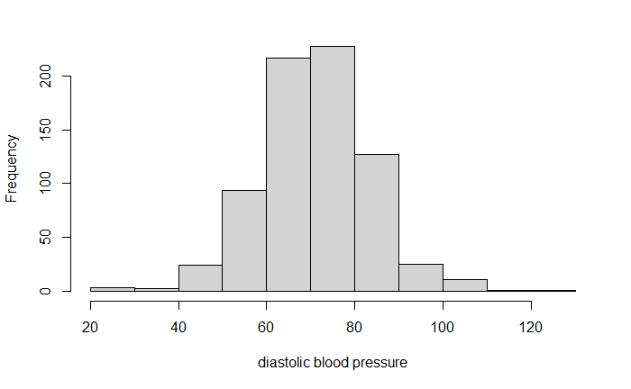

```r
hist(pima$dias, xlab = "diastolic blood pressure" , main="")
```

The histogram is approximately bell-shaped and centered around 70.

We can change the number of breaks in the histogram by specifying the `breaks` argument of the `hist` function.

Consider how the plot changes below.

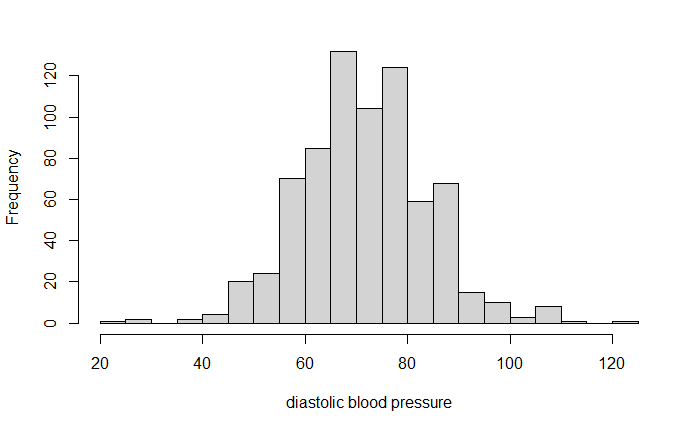

```r
hist(pima$dias, xlab = "diastolic blood pressure", main = "", breaks = 20)
```

### Density plots

Many people prefer the density plot over the histogram because the histogram is more sensitive to its options.

A density plot is essentially a smoothed version of a histogram.

- It isn’t as blocky.
- It sometimes has weird things happen at the boundaries.

The `plot` and `density` function can be combined to construct a density plot.

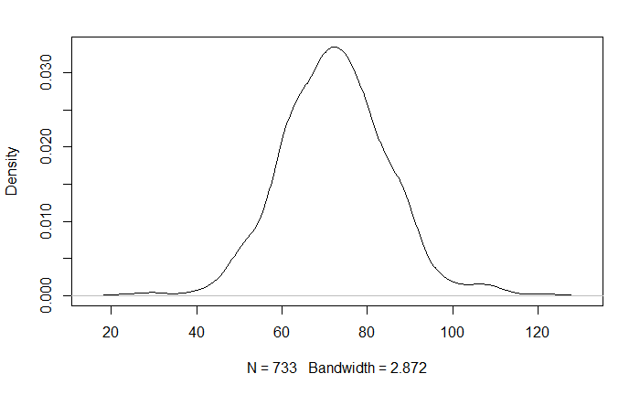

```r
plot(density(pima$diastolic, na.rm=TRUE), main = "")
```

In the example above, we have to specify `na.rm = TRUE` so that the density is only computed using the non-missing values.

### Index plots

An index plot is a scatter plot of a numerical variable versus the index of each value (i.e., the position it occurs in the vector).

- This is most useful for sorted vectors.

A scatter plot of the sorted numerical values versus their index can be used to identify outliers and see whether the data has many repeated values.

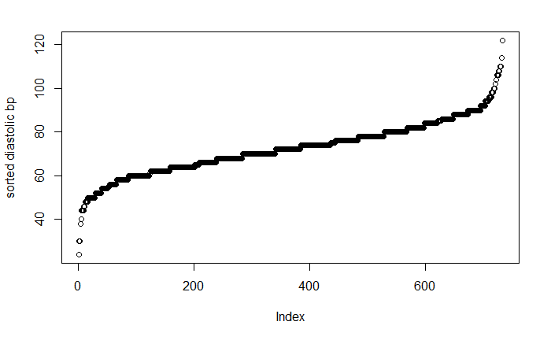

```r
plot(sort(pima$diastolic), ylab = "sorted diastolic bp")
```

The flat spots in the plot above show that the `diastolic` variable has mean repeated values.

### Bivariate scatter plots

Bivariate scatter plots can be used to identify the relationship between two numerical variables.

A scatter plot of diabetes vs diastolic blood pressure.

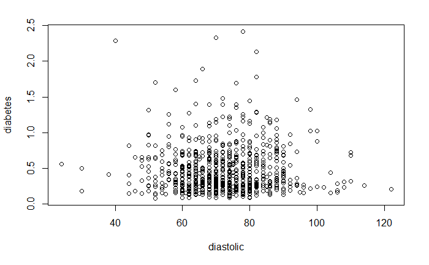

```r
plot(diabetes ~ diastolic, data = pima)
```

There is no clear pattern in the points, so it’s difficult to claim a relationship between the two variables.

### Bivariate boxplots

A parallel boxplot of `diabetes` score versus `test` result.

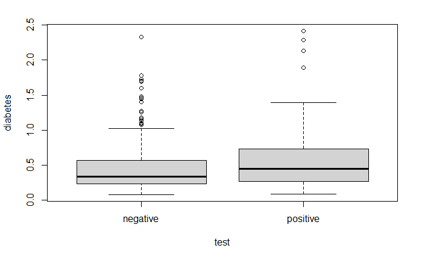

```r
plot(diabetes ~ test, data = pima)
```

The median `diabetes` score seems to be a bit higher for positive tests in comparison to the negative tests.

### Multiple plots in one figure

The `par` function can be used to construct multiple plots in one figure.

- The `mfrow` argument can be used to specify the number of rows and columns of plots you need.

A 1 by 2 set of plots is shown below.

```r
par(mfrow = c(1, 2))
plot(diabetes ~ diastolic, data = pima)
plot(diabetes ~ test, data = pima)
```

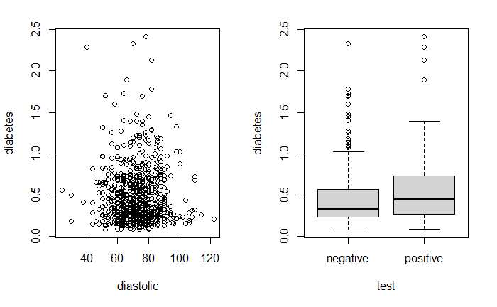

```r
par(mfrow = c(1, 1)) # reset to a single plot
```

## Visualizing data with **ggplot2**

The plots we have just created are using the **base** graphics system in R.

- These are very fast, simple, and professional.

A fancier alternative is to construct plots using the **ggplot2** package.

In its simplest form, to construct a (useful) plot in **ggplot2**, you need to provide:

- A `ggplot` object.
  - This is usually the object that holds your data frame.
  - The data frame is passed to `ggplot` via the `data` argument.
- A geometry object
  - Roughly speaking, this is the *kind* of plot you want.
  - e.g., `geom_hist` for a histogram, `geom_point` for a scatter plot, `geom_density` for a density plot.
- An aesthetic mapping
  - Aesthetic mappings describe how variables in the data are mapped to visual properties of a geometry.
  - This is where you specify which variable with be the `x` variable, the `y` variable, which variable will control plots in the color, etc.

### A **ggplot2** histogram

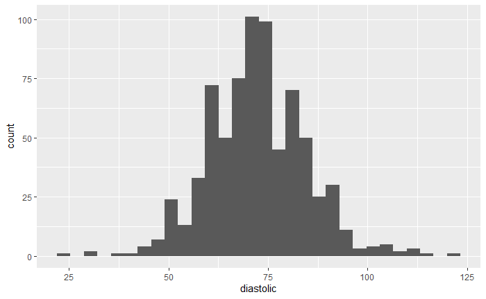

```r
library(ggplot2)
ggpima <-  ggplot(pima)
ggpima + geom_histogram(aes(x=diastolic))
```

### A **ggplot2** density plot

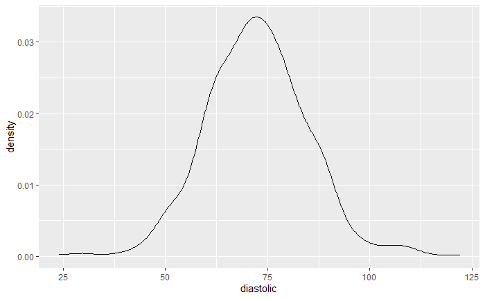

```r
ggpima + geom_density(aes(x = diastolic))
```

### A **ggplot2** scatter plot

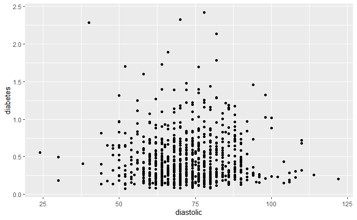

```r
ggpima + geom_point(aes(x = diastolic, y = diabetes))
```

### Scaling **ggplot2** plots

In general, *scaling* is the process by which **ggplot2** maps variables to unique values. When this is done for discrete variables, **ggplot2** will often scale the variable to distinct colors, symbols, or sizes, depending on the aesthetic mapped.

In the example below, we map the `test` variable to the `shape` aesthetic, which is then scaled to different shapes for the different `test` levels.

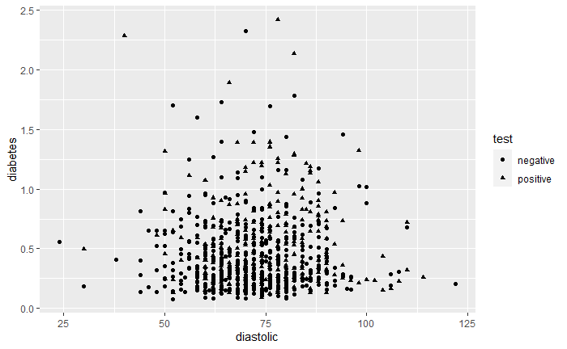

```r
ggpima +
  geom_point(aes(x = diastolic, y = diabetes, shape = test))
```

Alternatively, we can map the `test` variable to the `color` aesthetic, which creates a plot with different colors for each observation based on the `test` level.

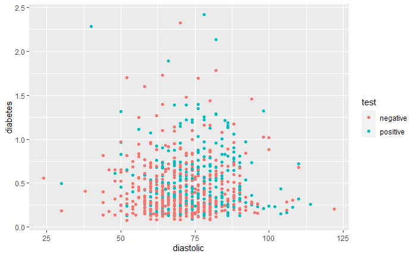

```r
ggpima +
  geom_point(aes(x = diastolic, y = diabetes, color = test))
```

We can even combine these two aesthetic mappings in a single plot to get different colors and symbols for each level of `test`.

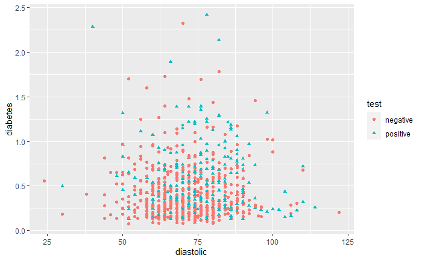

```r
ggpima +
  geom_point(aes(x = diastolic, y = diabetes, shape = test, color = test))
```

### Facetting in `ggplot2`

Facetting creates separate panels (facets) of a data frame based on one or more facetting variables.

Below, we facet the data by the `test` result.

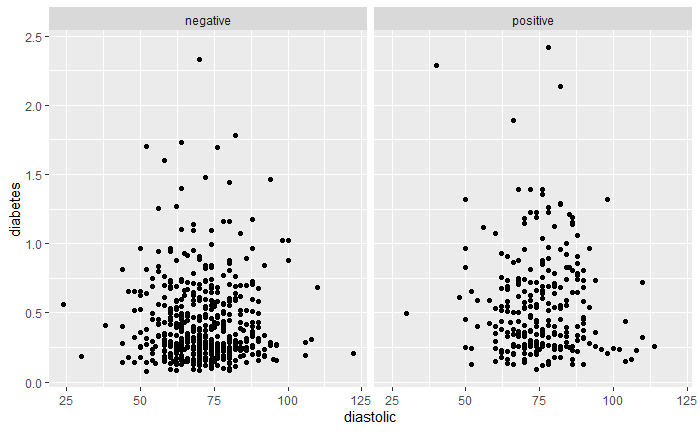

```r
ggpima +
  geom_point(aes(x = diastolic, y = diabetes)) +
  facet_grid(~ test)
```

### Summary of **ggplot2**

To create a **ggplot2** plot:

- Create a`ggplot` object using the `ggplot` function.
  - Specify the data frame the data is contained in (e.g., the data frame is `pima`).
- Specify the geometry for the plot (the kind of plot you want to produce)
- Specify the aesthetics using `aes`.
  - The aesthetic specifies what you see, such as position in the $x$ or $y$ direction or aspects such as shape or color.
  - The aesthetic can be specifed in the geometry, or if you have consistent aesthetics across multiple geometries, in the `ggplot` statement.

The advantage of **ggplot2** is more apparent in producing complex plots involving more than two variables.

- **ggplot2** makes it easy to plot the data for each group with different colors, symbols, line types, etc.
- **ggplot2** will automatically provide a legend mapping the attributes to the different groups. * You can easily facet the data into multiple panels.

## Summary of data exploration

You should use both numerical and graphical summaries of data **prior** to modeling data.

Data exploration helps us to:

- Gain understanding about our data
- Identify problems or unusual features of our data
- Identify patterns in our data
- Decide on a modeling approach for the data
- etc.